# Practical Machine Learning Project

2023-06-09

The data used in this project was originally collected with the goal of determining if it is possible to predict whether a particular exercise is being done correctly. Six men between the ages of 20 and 28 with little weightlifting experience were asked to perform repetitions of dumbbell bicep curls in five different ways (corresponding to the variable `classe` in the dataset). The value `classe = A` corresponds to the correct way to do the exercise, while values B, C, D, and E represent common mistakes that occur while doing the exercise.

After reading in the provided `pml_training` dataset, I split it into training and test sets. The training set initially contained 160 variables. After exploring these variables in the training set through summary tables and visualizations, I noticed that a large number of the columns contain summary statistics, all of which have a high proportion of missing values or `#DIV/0!` errors. Rather than impute for missing values, I chose to drop these summary statistic columns and only use the raw sensor variables to fit a model. After removing the summary statistics columns, the new training set contained 60 features.

```r
#Split pml_training into training and test sets:
set.seed(3478)
inTrain <- createDataPartition(y = pml_training$classe, p = 0.7, list = FALSE)
training <- pml_training[inTrain,]
testing <- pml_training[-inTrain,]
```

After further exploration, I noticed that each male participant (identified by the `user_name` variable) seems to be associated with a particular time stamp value. As a result, I decided to remove the three time stamp variables (`raw_timestamp_part_1`, `raw_timestamp_part_2`, and `cvtd_timestamp`), as well as the identifier `user_name`, leaving 56 features.

Finally, I explored the window features. Most of the observations have `new_window = no`, as seen in the bar chart below. Also, `num_window` appears to be some sort of index variable for the raw measurements. I decided to eliminate both window variables since they do not appear to be good predictors of `classe`, and I also eliminated the first column `X` since it appears to be an index variable, leaving a total of 53 features.

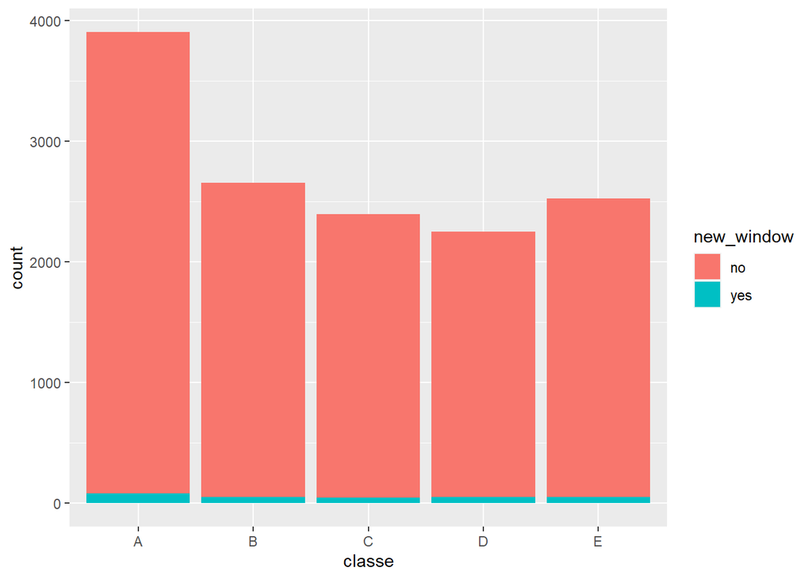

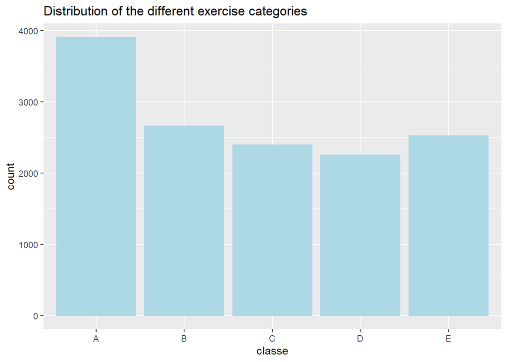

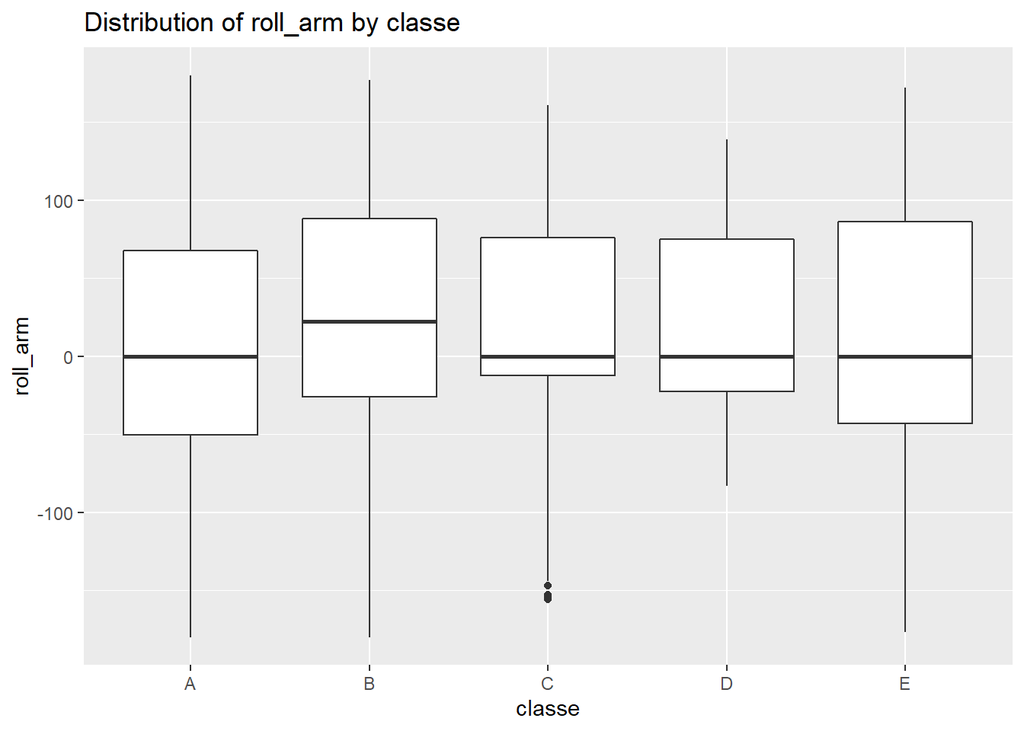

I decided to first train a random forest model to predict `classe`. I chose a random forest since they tend to have good predictive performance with relatively little hyperparameter tuning. For the first model, I used the defaults in the `train()` method from the `caret` package, which means the default resampling method used was the bootstrap. The model code took an extremely long time to run, however. In an attempt to improve run time, I decided to train a random forest model again, but this time using 10-fold cross-validation for model tuning. In practice, choosing k = 10 appears to be a good choice for bias-variance trade-off. This method will also give an estimate of the out-of-sample error since for a random forest the out-of-bag (OOB) error estimate is equivalent to the out-of-sample error estimate calculated using other approaches. However, I think it is beneficial to estimate the out-of-sample error using data that was not used to calculate the model parameters. So I used an additional holdout set to make predictions and calculate the out-of-sample error estimate.

Looking at the variable importance plot below, we see that the variables with the largest mean decrease in Gini index are `roll_belt`, `pitch_forearm`, and `yaw_belt`.

```r
#Random forest model using 10-fold cross-validation
#This model runs considerably faster than using the default bootstrap)
mod_rf_cv <- train(classe ~ ., data = training, method = "rf",
                trControl = trainControl(method = "cv", number = 10))

mod_rf_cv
```

```
## Random Forest
##
## 13737 samples
##    52 predictor
##     5 classes: 'A', 'B', 'C', 'D', 'E'
##
## No pre-processing
## Resampling: Cross-Validated (10 fold)
## Summary of sample sizes: 12362, 12363, 12363, 12364, 12364, 12365, ...
## Resampling results across tuning parameters:
##
##   mtry  Accuracy   Kappa
##    2    0.9911190  0.9887654
##   27    0.9911926  0.9888598
##   52    0.9868250  0.9833338
##
## Accuracy was used to select the optimal model using the largest value.
## The final value used for the model was mtry = 27.
```

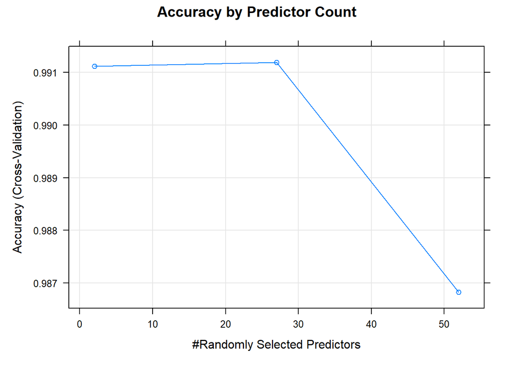

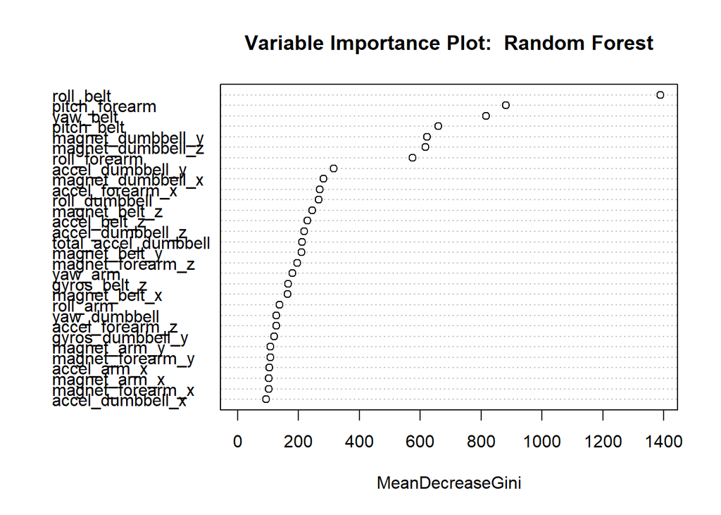

The code below uses a holdout set to estimate the out-of-sample error. The expected out-of- sample error for this model was 0.009 and it took considerably less run time to train. Since the accuracy for this model is already at 99.1%, I decided not to tune the model any further (again, one of the benefits of random forests is their out-of-box performance).

```r
#select features for the testing set:
testing <- testing %>%
  select(!starts_with(c("kurtosis_", "skewness_", "max_", "min_",
                        "amplitude_", "var_", "avg_", "stddev_")))

testing <- testing %>%
  select(!c("raw_timestamp_part_1", "raw_timestamp_part_2", "cvtd_timestamp", "user_name", "X", "new_window", "num_window"))

pred <- predict(mod_rf_cv, testing)

#Estimate of the out of sample error = 1 - accuracy:
testing$classe <- as.factor(testing$classe)
confusionMatrix(pred, testing$classe)
```

```
## Confusion Matrix and Statistics
##
##           Reference
## Prediction    A    B    C    D    E
##          A 1665   10    0    0    0
##          B    8 1123    7    0    0
##          C    0    6 1019   15    4
##          D    0    0    0  949    2
##          E    1    0    0    0 1076
##
## Overall Statistics
##
##                Accuracy : 0.991
##                  95% CI : (0.9882, 0.9932)
##     No Information Rate : 0.2845
##     P-Value [Acc > NIR] : < 2.2e-16
##
##                   Kappa : 0.9886
##
##  Mcnemar's Test P-Value : NA
##
## Statistics by Class:
##
##                      Class: A Class: B Class: C Class: D Class: E
## Sensitivity            0.9946   0.9860   0.9932   0.9844   0.9945
## Specificity            0.9976   0.9968   0.9949   0.9996   0.9998
## Pos Pred Value         0.9940   0.9868   0.9761   0.9979   0.9991
## Neg Pred Value         0.9979   0.9966   0.9986   0.9970   0.9988
## Prevalence             0.2845   0.1935   0.1743   0.1638   0.1839
## Detection Rate         0.2829   0.1908   0.1732   0.1613   0.1828
## Detection Prevalence   0.2846   0.1934   0.1774   0.1616   0.1830
## Balanced Accuracy      0.9961   0.9914   0.9940   0.9920   0.9971
```

```r
sum(pred != testing$classe)/length(testing$classe)
```

```
## [1] 0.009005947
```